# Analysis of Activity Monitoring Data

Sagi Ganot

## Introduction

This report makes use of data from a personal activity monitoring device. This device collects data at 5 minute intervals through out the day. The data consists of two months of data from an anonymous individual collected during the months of October and November, 2012 and include the number of steps taken in 5 minute intervals each day. The data was analyzed using R and this report is produced using Rmarkdown and knitr, containing the code used for the analysis as well as the results.

## Setup

This section sets up the R working environment and loads the relevant libraries.

```r
knitr::opts_chunk$set(echo = TRUE)
Sys.setlocale(category = "LC_ALL", locale = "english")
```

```
## [1] "LC_COLLATE=English_United States.1252;LC_CTYPE=English_United States.1252;LC_MONETARY=English_United States.1252;LC_NUMERIC=C;LC_TIME=English_United States.1252"
```

```r
library(plyr)
library(lattice)
```

## Loading data

This section loads the data.

```r
data <- read.csv("activity.csv")
data$date <- as.Date(data$date)
```

## Sum of steps by day

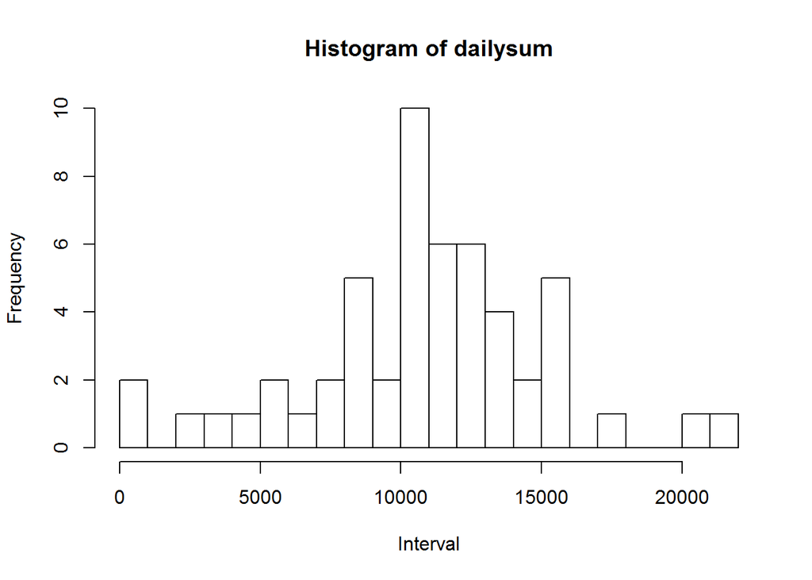

```r
dailysum <- tapply(data$steps,data$date,sum)
hist_dailysum <- hist(dailysum,breaks=20,xlab="Interval")
```

```r
mean_dailysum <- mean(dailysum,na.rm=TRUE)
median_dailysum <- median(dailysum,na.rm=TRUE)
```

## Average steps by interval

This section calculates the average number of steps for 5-minute intervals across all days, generates a plot showing the average throughout the day, and calculates the 5-minute interval for which the average is highest.

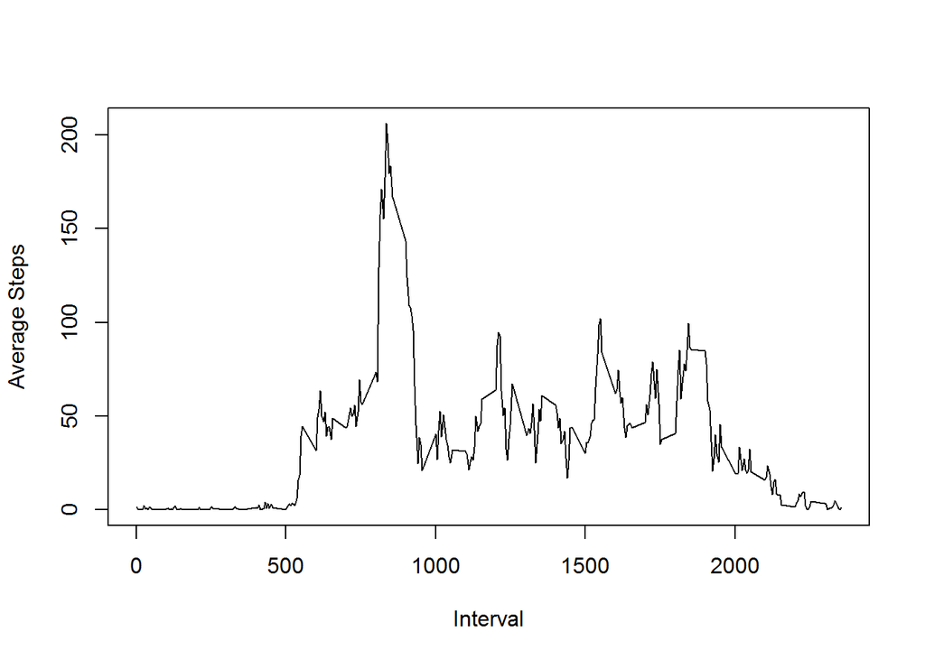

```r
pattern <- tapply(data$steps,data$interval,mean,na.rm=TRUE)
pattern2 <- data.frame(cbind(as.numeric(row.names(pattern)),pattern))
plot(pattern2,type="l",xlab="Interval",ylab="Average Steps")
```

```r
max_int <- pattern2[which.max(pattern),1]
max_steps <- max(pattern)
```

The 5-minute interval with the highest average (206.1698113) is 835.

## Imputation of missing values

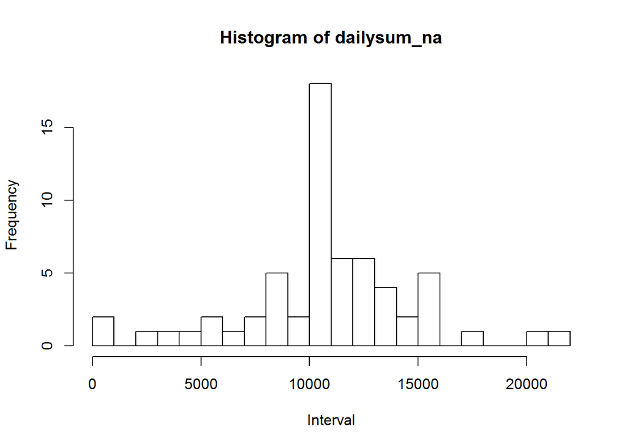

```r
no_missing <- nrow(data)-nrow(data[complete.cases(data),])
data2 <- data
for (i in c(1:nrow(data2))) if (is.na(data2[i,1])) data2[i,1] <- pattern2[paste(data2[i,3]),2]
dailysum_na <- tapply(data2$steps,data2$date,sum)
hist_dailysum_with_na <- hist(dailysum_na,breaks=20,xlab="Interval")
```

```r
mean_dailysum_with_na <- mean(dailysum_na,na.rm=TRUE)
median_dailysum_with_na <- median(dailysum_na,na.rm=TRUE)
```

## Analysis by weekdays

The observations are separated into weekdays and weekends, and a panel plot is produced of the average number of steps for each 5-minute interval for each of the two categories.

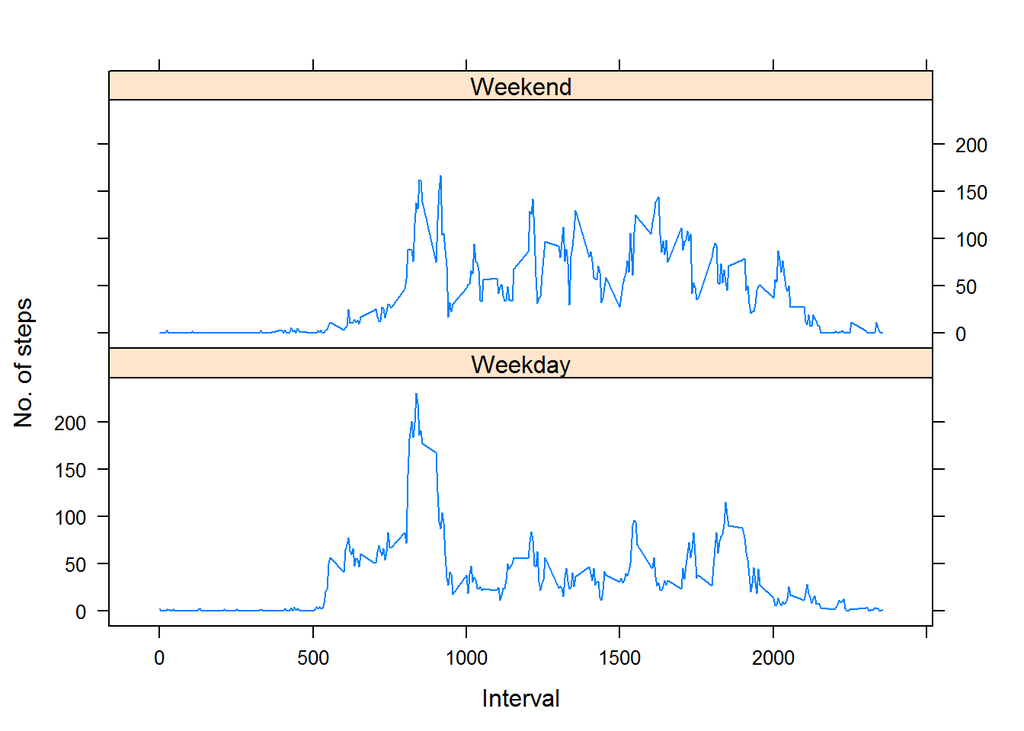

```r
data3 <- mutate(data2,wd=weekdays(data2$date))
for (i in 1:nrow(data3)) if (data3[i,4] %in% c("Saturday","Sunday")) data3[i,4] <- "Weekend" else data3[i,4] <- "Weekday"
wd_interval <- aggregate(data3$steps,by=list(data3$interval,data3$wd),FUN=mean)
xyplot(x ~ Group.1 | Group.2, data = wd_interval, layout=c(1,2),type="l",xlab="Interval",ylab="No. of steps")
```